#Лабораторный практикум ВКИАД c R

**Преподаватель**

```
Дернакова Оксана Владимировна
```

**Студент**

```
Семененко Алексей Викторович, 2 курс, 6 группа, ПМ
```

**Вариант № 5**

### Часть 1. Управление данными в R

Загрузка данных из текстового файла в таблицу данных

```r
qc <- read.table("QC5.txt")
```

Размерность таблицы

```r
dim(qc)
```

```
## [1] 100   9
```

Первые три записи из таблицы

```r
head(qc, 3)
```

```
##      V1 V2 V3 V4 V5    V6     V7     V8 V9
## 1  9.13  2  2  1  4 31.18 16.644 76.125  7
## 2  9.11  2  3  1  4 31.88 18.210 82.050  6
## 3 11.53  5  1  1  4 30.96 19.536 86.490  6
```

Таблица после переименования переменных

```r
colnames(qc) <- c("c1", "kit", "nbug", "maker", "vendor", "c2", "c3", "c4", "bug")
head(qc)
```

```
##      c1 kit nbug maker vendor    c2     c3     c4 bug
## 1  9.13   2    2     1      4 31.18 16.644 76.125   7
## 2  9.11   2    3     1      4 31.88 18.210 82.050   6
## 3 11.53   5    1     1      4 30.96 19.536 86.490   6
## 4  9.45   1    1     1      3 30.42 18.783 84.645   7
## 5  8.40   6    2     2      3 32.76 17.760 79.035   4
## 6 10.73   2    5     1      2 32.56 18.675 82.890   7
```

Комплексная статистика по переменной vendor

```r
summary(qc$vendor)
```

```
##    Min. 1st Qu.  Median    Mean 3rd Qu.    Max.
##    1.00    2.00    3.00    2.87    4.00    4.00
```

Комплексная статистика по переменной vendor после ее преобразования в переменную-фактор

```r
qc[, "vendor"] <- as.factor(qc[, "vendor"])
summary(qc[, "vendor"])
```

```
##  1  2  3  4
## 14 23 25 38
```

Число изделий, у которых количество некритических дефектов больше 3

```r
sum(qc$nbug > 3)
```

```
## [1] 14
```

Наблюдения, для которых количество некритических дефектов равно максимальному

```r
qc[qc$nbug == max(qc$nbug),]
```

```
##      c1 kit nbug maker vendor    c2     c3    c4 bug
## 93 9.12   5    7     2      4 37.35 17.877 79.71   8
```

### Часть 2. Описательная статистика и графический анализ

Присоединение таблицы данных к списку текущих переменных и загрузка дополнительной библиотеки

```r
attach(qc)
library("e1071")
```

Выборочные среднее и медиана для переменной с1 в указанном порядке

```r
mean(c1)
```

```
## [1] 9.9823
```

```r
median(c1)
```

```
## [1] 10.08
```

Выборочные квартили Q1,Q2,Q3, а также интерквартильный размах для переменной c1

```r
quantile(c1, probs = c(0.25, 0.5, 0.75))
```

```
##     25%     50%     75%
##  9.4350 10.0800 10.6275
```

```r
IQR(c1)
```

```
## [1] 1.1925
```

Комплексная статистика по переменной c1

```r
summary(c1)
```

```
##    Min. 1st Qu.  Median    Mean 3rd Qu.    Max.
##   7.290   9.435  10.080   9.982  10.627  11.890
```

Дисперсия для переменной с1 и переменной 2 * с1 + 100

```r
var(c1)
```

```
## [1] 0.8576522
```

```r
var(2 * c1 + 100)
```

```
## [1] 3.430609
```

**ВЫВОД**: Вторая дисперсия больше первой в 4 раза

Дисперсия для переменной с1, полученная с помощью векторного выражения

```r
sum(mean(c1 * c1) - (mean(c1))^2) * length(c1) / (length(c1) - 1)
```

```
## [1] 0.8576522
```

Гистограмма для переменной с1

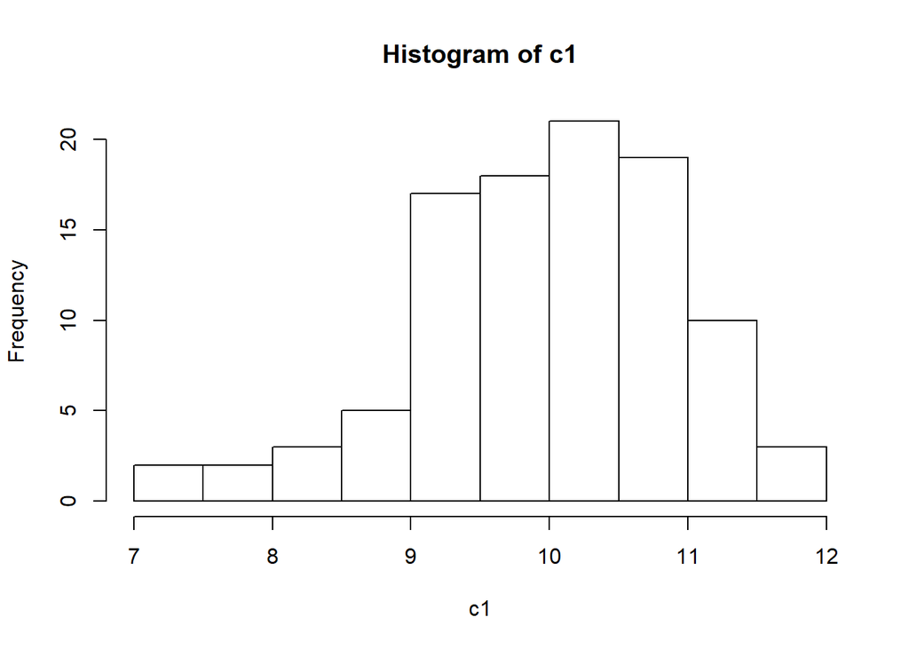

```r
hist(c1)
```

Асимметрия и эксцесс для переменной c1 в указанном порядке

```r
skewness(c1)
```

```
## [1] -0.524337
```

```r
kurtosis(c1)
```

```
## [1] 0.2658718
```

Проверка распределения переменной c1 на нормальность с помощью статистического теста Лиллиефорса

```r
library(nortest)
lillie.test(c1)
```

```
##
##  Lilliefors (Kolmogorov-Smirnov) normality test
##
## data:  c1
## D = 0.05934, p-value = 0.523
```

**ВЫВОД**: Гипотеза о нормальном распределении принимается на уровне значимости 0.05.

### Часть 3. Анализ статистических зависимостей

Перекодирование переменной kit в переменную с двумя значениями (1 и 2)

```r
kit <- ifelse(kit < 3, 1, 2)
```

Ранговый коэффициент корреляции Спирмена для переменных kit и maker

```r
cor(kit, maker, method = "spearman")
```

```
## [1] 0.09929932
```

Таблица сопряженности для переменных kit и maker

```r
table(kit, maker)
```

```
##    maker
## kit  1  2
##   1 29 22
##   2 23 26
```

**ВЫВОД**: Согласно ранговому коэффициенту корреляции и таблице сопряженности согласованность между переменными практически отсутствует.

Тест на равенство нулю коэффициента корреляции для переменных с1 и с3

```r
cor.test(c1, c3)
```

```
##
##  Pearson's product-moment correlation
##
## data:  c1 and c3
## t = 7.1113, df = 98, p-value = 1.891e-10
## alternative hypothesis: true correlation is not equal to 0
## 95 percent confidence interval:
##  0.4370890 0.6996605
## sample estimates:
##       cor
## 0.5834193
```

**ВЫВОД**: Гипотеза о равенстве нулю коэффициента корреляции между переменными отклоняется на уровне значимости 0.05.

Корреляционная матрица для числовых характеристик с1-c4

```r
mCor = cor(qc[, c(1, 6:8)])
mCor
```

```
##              c1           c2          c3          c4
## c1  1.000000000 -0.009795793  0.58341933 0.539350201
## c2 -0.009795793  1.000000000 -0.01003422 0.003347985
## c3  0.583419330 -0.010034222  1.00000000 0.875068389
## c4  0.539350201  0.003347985  0.87506839 1.000000000
```

Матрица корреляции в удобном представлении

```r
symnum(mCor)
```

```
##    c1 c2 c3 c4
## c1 1
## c2    1
## c3 .     1
## c4 .     +  1
## attr(,"legend")
## [1] 0 ' ' 0.3 '.' 0.6 ',' 0.8 '+' 0.9 '*' 0.95 'B' 1
```

**ВЫВОД**: Наибольший коэффициент корреляции наблюдается между переменными c3 и c4.

Построение регрессионной модели по переменным c3 (зависимая - отклик) и c4(независимая - фактор) и вывод общей статистики по результатам оценивания

```r
summary(linmod <- lm(c3 ~ c4))
```

```
##
## Call:
## lm(formula = c3 ~ c4)
##
## Residuals:
##      Min       1Q   Median       3Q      Max
## -0.97424 -0.18813  0.00769  0.20639  0.81522
##
## Coefficients:
##             Estimate Std. Error t value Pr(>|t|)
## (Intercept)  0.07915    1.01429   0.078    0.938
## c4           0.22110    0.01235  17.898   <2e-16 ***
## ---
## Signif. codes:  0 '***' 0.001 '**' 0.01 '*' 0.05 '.' 0.1 ' ' 1
##
## Residual standard error: 0.3407 on 98 degrees of freedom
## Multiple R-squared:  0.7657, Adjusted R-squared:  0.7634
## F-statistic: 320.3 on 1 and 98 DF,  p-value: < 2.2e-16
```

**ВЫВОД**: Значим (на уровне 0.05) только коэффицент при независимой переменной с4. Статистика R-квадрат принимает значение 0.7657.

Диаграмма рассеяния с линией регрессии для переменных c3 и c4.

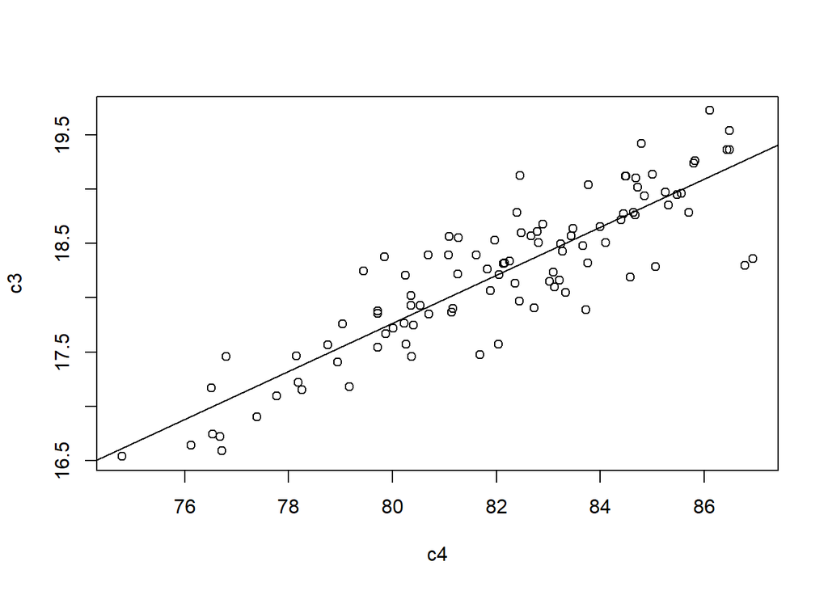

```r
plot(c3 ~ c4)
abline(linmod)
```

Коэффициенты регрессионной модели

```r
coefficients(linmod)
```

```
## (Intercept)          c4
##  0.07914987  0.22109796
```

График “Квантиль-квантиль” для остатков модели

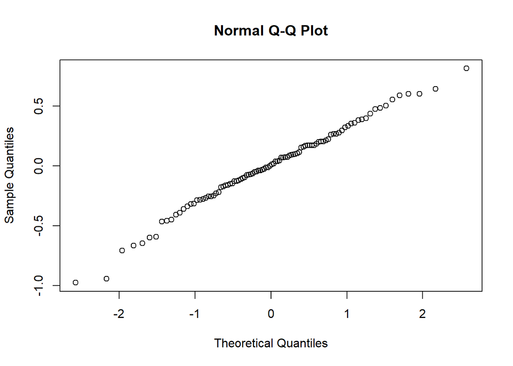

```r
res = residuals(linmod)
qqnorm(res)
```

**ВЫВОД**: Большинство точек располагаются вблизи прямой линии, поэтому распределение остатков близко к нормальному.

Тест Колмогорова-Смирнова на нормальность остатков

```r
ks.test(res, pnorm, mean(res), sd(res))
```

```
##
##  One-sample Kolmogorov-Smirnov test
##
## data:  res
## D = 0.049693, p-value = 0.9659
## alternative hypothesis: two-sided
```

**ВЫВОД**: Критерий принимает гипотезу о нормальном распределении остатков на уровне значимости 0.05.

### Часть 4. Анализ неоднородных данных

Частоты значений для переменной maker.

```r
table(maker)
```

```
## maker
##  1  2
## 52 48
```

Двухвыборочный t-критерий по переменной, для которой наблюдается значимое различие средних в двух подвыборках (по значениям переменной maker), c разбиением на подвыборки по переменной maker.

```r
tc1 = t.test(c1 ~ maker)
tc2 = t.test(c2 ~ maker)
tc3 = t.test(c3 ~ maker)
tc4 = t.test(c4 ~ maker)
min = min(c(tc1$p.value, tc2$p.value, tc3$p.value, tc4$p.value))
if (tc1$p.value == min) tc1
if (tc2$p.value == min) tc2
```

```
##
##  Welch Two Sample t-test
##
## data:  c2 by maker
## t = -8.5391, df = 94.451, p-value = 2.26e-13
## alternative hypothesis: true difference in means is not equal to 0
## 95 percent confidence interval:
##  -2.738593 -1.705349
## sample estimates:
## mean in group 1 mean in group 2
##        32.01115        34.23313
```

```r
if (tc3$p.value == min) tc3
if (tc4$p.value == min) tc4
```

**ВЫВОД**: Гипотеза о равенстве средних в двух подвыборках отклоняется на уровне значимости 0.05 для переменной c2 (средние значения характеристики c2 у двух производителей статистически различимы).

Построить “ящик с усами” для анализируемой переменной в разрезе по номеру производителя (maker).

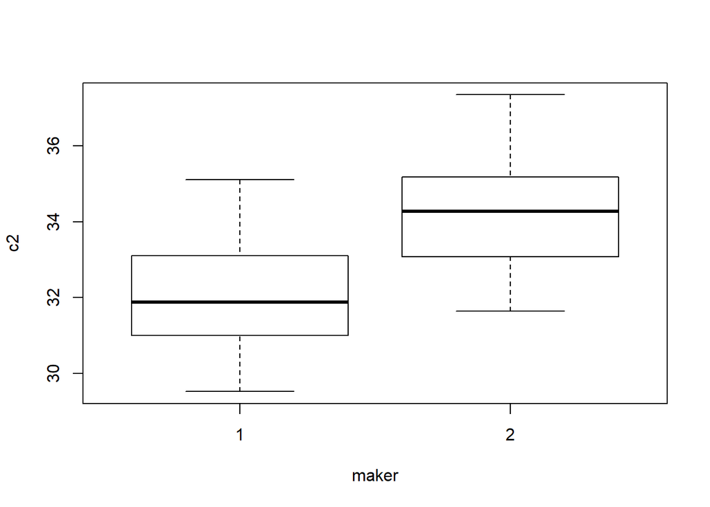

```r
boxplot(c2~maker)
```

Построить график ядерной оценки плотности распределения (density) для анализируемой переменной.

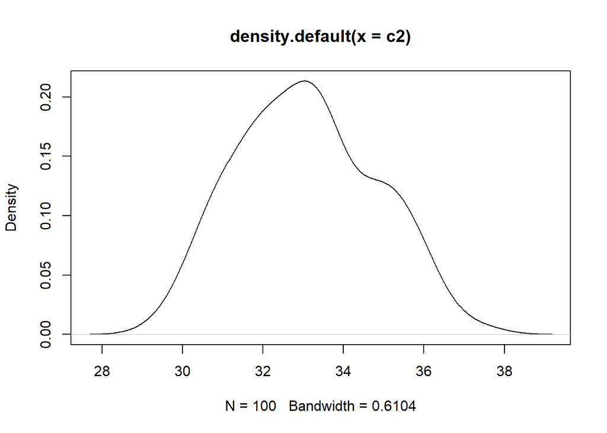

```r
plot(density(c2))
```

**ВЫВОД**: Из графика видно, что выборка описывается моделью, которая представляет собой смесь двух распределений.

### Часть 5. Классификация неоднородных данных

Отсоединить таблицу данных qc от списка текущих переменных (работа с данными закончена).

```r
detach(qc)
```